# 이력서

김은서

2022-06-18

# 경력사항

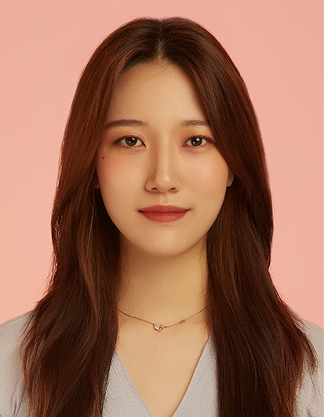

## 용남고등학교 대입 상담

직원유형: 아르바이트 입사월: 2018-01 퇴사월: 2018-02

## 부라더치킨 서빙

직원유형: 아르바이트  
입사월: 2018-03  
퇴사월: 2018-06

## 투고샐러드 셰프

직원유형: 아르바이트  
입사월: 2018-03  
퇴사월: 2018-06

## 미니스톱 캐셔

직원유형: 아르바이트  
입사월: 2018-07  
퇴사월: 2019-02

## GS25 캐셔

직원유형: 아르바이트 입사월: 2018-09 퇴사월: 2019-06

## CU 캐셔

직원유형: 아르바이트 입사월: 2019-07 퇴사월: 2019-09

## 잠실 소재 수학 학원 강사

직원유형: 계약직 입사월: 2019-08 퇴사월: 2019-12

## 파크짐 인포

직원유형: 계약직 입사월: 2021-12 퇴사월: 2022-02

# 프로젝트 수행 이력

## **자율주행 전기자동차 시제품 제작**

당해년도: 2022년

## **‘열연공정 표면 결함 검출의 머신러닝 알고리즘 비교’ 학위논문**

당해년도: 2022년

[논문 서론 첨부]

국가 정책의 영역까지 인공지능이 들어오게 된 것은 2010년대 이후 심층학습(Deep Learning)이라는 기술이 비약적으로 발전한 뒤로, 단 10년 정도에 불과하다. 2012년 심층 신경망(Deep Neural Network) ’알렉스넷(AlexNet)’이 등장하자마자 당시 가장 낮은 이미지 식별 에러율이었던 26%을 압도적으로 앞서는 16%를 선보이며 놀라운 성과를 보였다. 2015년 딥러닝을 적용한 이미지 분류 모델의 등장 이후 단 3년만에 마이크로소프트의 ’레지넷(ResNet)’이 3.56%의 에러율에 도달하며 인간의 에러율로 알려진 5%를 이기게 된다. 이러한 급속한 인공지능의 발전으로 인해 산업과 사회 전반에 걸쳐 핵심 기술로 부상하였고, 여러 국가 및 기업에서 AI 마스터플랜을 수립하기 시작했다. 우리 정부도 디지털 뉴딜 사업의 일환으로서 공장의 자동화를 위한 스마트공장 지원 사업을 진행하고 있으며, 2022년까지 스마트공장 3만개 보급을 목표로 다양한 사업을 추진중에 있다 (중소벤처기업부, 2018). 하지만, 세계적으로 보았을 때 생산제조 분야에서 인공지능을 도입한 비율은 12%에 불과하다 (강송희, 2021). 한국의 경우 GDP 대비 제조업 비중이 25%를 상회하는 제조업 중심의 나라이다 (한국저작권위원회, 2019). 따라서 국가 경쟁력을 위해 제조업 분야에서의 인공지능 활용을 통한 생산성 향상은 필수적이다. 하지만 인공지능을 공정에 적용하기 위해서는 데이터 수집, 데이터 전처리, 모델 생성 및 개선, 그리고 실제 공정에 도입까지 일련의 과정을 거쳐야 한다. 하지만 대부분의 기업들은 지식과 전문 인력의 부족으로 도입에 어려움을 겪고 있다. 제품 설계, 모니터링 및 수요 예측 등 다양한 분야에서 인공지능을 적용하여 효율성의 개선이 가능하다. 그 중에서도 검사 공정은 일반적인 제조 공정에서 품질관리를 위해 필수적인 데 반해 여전히 대부분 영상처리 기반의 비전검사 혹은 사람의 육안에 의해 이루어진다. 이로 인해서 많은 공장의 검사 공정에서 병목 현상이 일어나고 있다. 사람의 육안으로 부품 불량 여부를 판단할 경우, 노동자의 피로도나 주관적 기준에 따라 검사 품질이 일관되지 않을 수 있다. 미세 결함을 검출해야 하는 경우나, 육안으로 판단하는 데 시간이 오래 걸리는 경우에는 이러한 문제들이 더욱 부각된다. 또한 최저임금 상승 등의 영향으로 인건비가 상승하고 있어 검사 공정에서의 비용부담 또한 늘고 있다.

## **굿노트 템플릿 공유사이트 베타버전 출시**

당해년도: 2020년

## **‘제주공항 확장사업 예비타당성 보고서’ 정책검토 및 사후평가**

당해년도: 2019년

# 학력 정보

| 학교명 | 캠퍼스 | 주전공 | 부전공 | 입학연월 | 졸업연월 | 졸업상태 |  |
| --- | --- | --- | --- | --- | --- | --- | --- |
| 한양대학교 | 서울 | 공과대학 산업공학과 | 물리학 | 2018.03 | 2023.02 | 재학중 |  |

# 언어능력

**파이썬**

**R**

**MySQL**

**아두이노**

**Shiny**

# 어학능력

## **TOEIC**

TOEIC 800점 취득년도: 2021년